# World Happiness Report 2019 - Multiple linear regression analysis

Fanni Kiss

2021-01-03

## Introduction

Current report attempts to show how six key variables contribute to explaining the full sample of national annual average happiness scores in the World Happiness Report 2019. These variables are GDP per capita, social support, healthy life expectancy, freedom to make life choices, generosity and perceptions of corruption. The values are scores by country, which are based on individuals’ own assessments of their lives. The six variables are used to explain the variation of happiness across countries.

[GitHub repository](https://github.com/fanni-k/DA2/tree/main/assignment_2)

# Data

The World Happiness Report is a publication of the Sustainable Development Solutions Network, powered by data from the Gallup World Poll. The cleaned data set is downloaded from [Kaggle](https://www.kaggle.com/unsdsn/world-happiness). Descriptive statistics and histograms of explanatory variables are shown in the appendix.

# Model

The correlations between the Happiness Score and GDP per capita, Social support and Heathy life expectancy were strong and positive, so first, I use a simple linear regression model to predict the Happiness Score based on one variable. Then we can observe, how accurate the predicted Happiness Score compared to the true values. After that, I use multiple linear regression model to predict the happiness score more precisely using the three variables simultaneously and then using all variables simultaneously.

## Simple Linear Regression

Firstly, I regress Happiness Score on GDP per capita. The multiple R-squared is 0.63, which means that GDP per capita explains 63% of the Happiness Score value. Also, the p-value of the coefficient of the GPD_per_capita variable is 0, so we can consider the predictor variable statistically significant. The regression table is shown in the appendix. The simple linear regression model is the next: Happiness Score (estimated) = 3.4 + 2.22 * GDP_per_capita The GDP per capita alone explains 63% of the Happiness Score. In the next section, I complete the regression model with further variables to predict more precisely the Happiness Score.

## Multiple Linear Regression Model I.

The World Happiness Report data set allows us to check, how do the six different variables explain the Happiness Score. I apply a multiple linear regression using the GDP per capita, social support, life expectancy, freedom to make life choices, generosity and corruption to see, how do these variables explain the Happiness Score. The result of the regression is a model, which tells us, how does the Happiness Score changes on average with one unit larger value of one variable but the same vaue of the rest of the variables. The multiple linear regression model for the World Happiness Report 2019 is the next: Happinnes Score (estimated) = 1.79 + 0.77 * GDP_per_capita + 1.12 * social_support + 1.08 * life_expectancy + 1.45 * freedom_of_choice + 0.49 * generosity + 0.97 * corruption The multiple R-squared values of the model is 0.78, which means that the six explanatory variables explain 78% of the Happinness Score. There are two variables, generosity and corruption, which confidence interval ranges involve zero. The interval that contains the true value of the regression coefficients can be both negative and positive by 95% probability. This means, that generosity and corruption explain weakly the Happiness Score in my analysis. Also, the p-values of generosity and corruption are high (0.41 and 0.16 consecutively), which means that generosity and corruption are not statistically significant predictor variables.

### Comparison of estimated and true value of Happiness Score (I.)

Due to the multiple linear regression model, we have estimated values for the Happiness Score. The plot below shows the estimated values and the true values. The smaller is the difference between the estimated value and the true value of the Happiness Score of a give country, the closer is the point to the 45 degree line. If the model would explain perfectly the Happiness Score, all the point would lie on the 45 degree line. However, in our case, the model does not explain all the Happiness Scores perfectly. There are countries, which are above the predicted happiness level and there are ones, which are below. Let us see, which ones are the top countries, that are the least well explained by the multiple linear regression model.

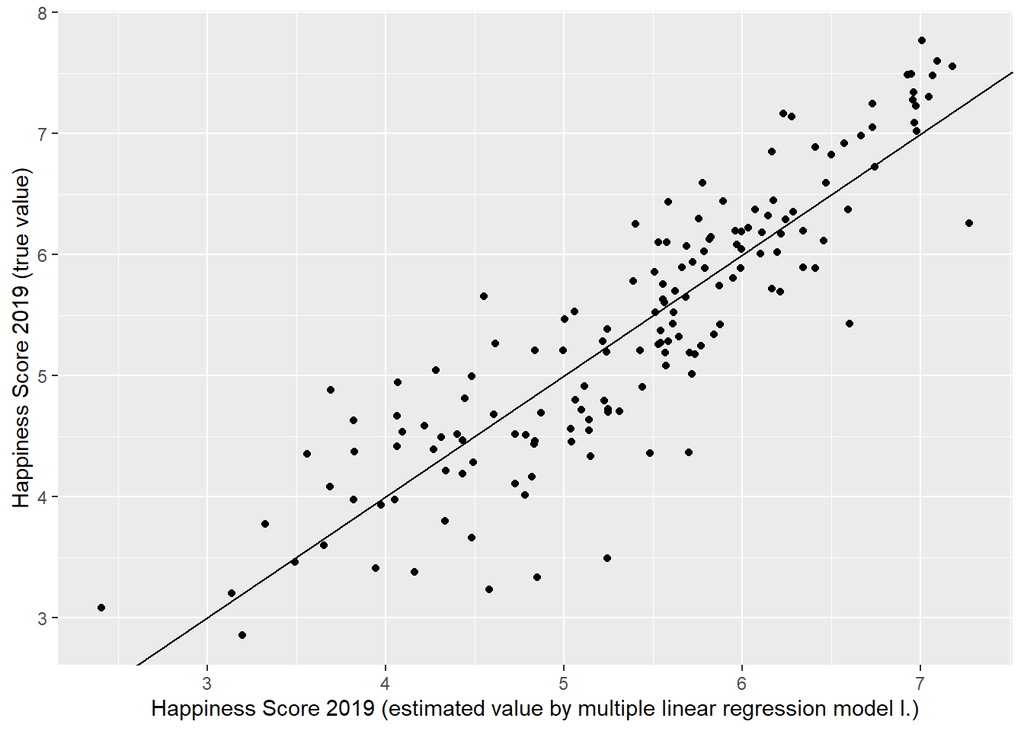

I set two threshold values to pick those countries, which shows a great difference between true Happiness Score value (y) and the estimated value (yE) based on my multiple linear regression model. Those countries, which shows higher than 0.8 difference between the true and the estimated value, are the “TOP Positive Countries”. The scatterplot below shows the countries which are “happier than they supposed to be” according to our multiple linear regression model. Benin, Pakistan, Costa Rica, Ivory Coast, Israel, El Salvador, Guatemala, Mexico and Niger have higher Happiness Score in the World Happiness Report than predicted by my multiple linear regression model. To understand the true value of the Happiness Score, we should consider to involve further explanatory variables into the multiple linear regression model, such as weather or connection to sea/ocean, as all of the countries have warm climate and most of them have connection to a sea or ocean.

Similarly, those countries, which shows lower than -1 difference between the true and the estimated value, are the “TOP Negative Countries”. The scatterplot below shows countries which are “less happier than they supposed to be” according to our multiple linear regression model. Botswana, Rwanda, Tanzania, Sri Lanka, Hong Kong, Myanmar and Singapore have lower Happiness Score in the World Happiness Report than the predicted value by my multiple linear regression model. The mentioned countries used to be part of a colony in the colonial period of the history. We might involve a dummy variable for further analysis to have a more precise model.

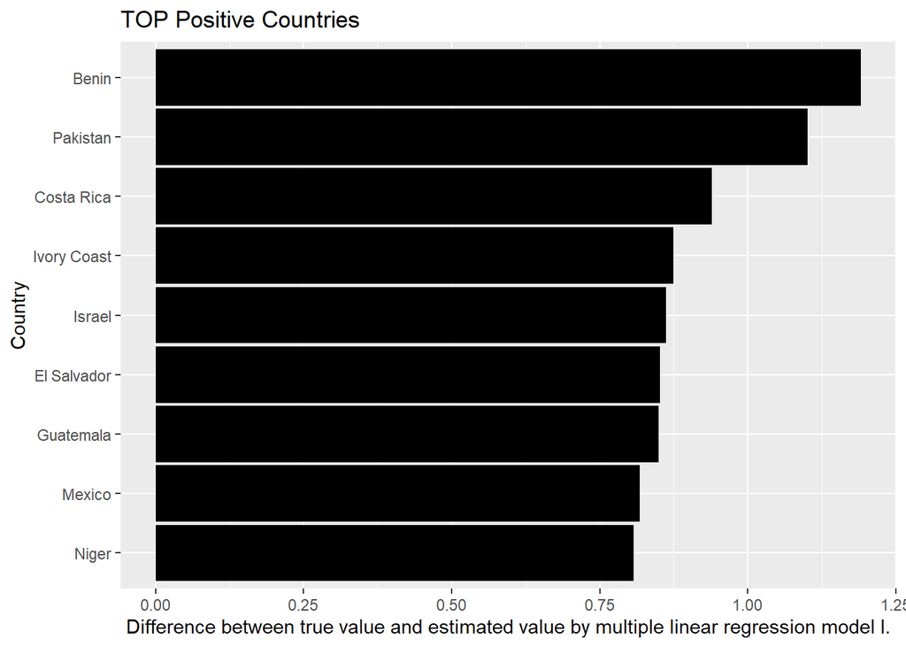

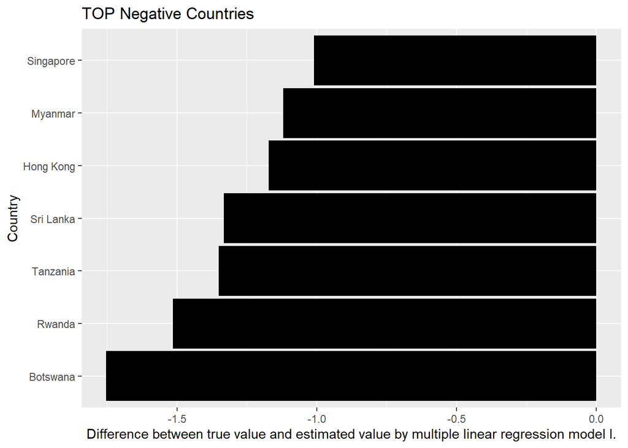

## Multiple Linear Regression Model II.

The second multiple linear regression model involves four explanatory variables to predict the Happiness Score: GDP_per_capita, Social_support, Life_expectancy and Freedom_of_choice. The R-squared value is 0.77, which means that these explanatory variables explain 77% of the Happiness Score. The result of the second model is the next: Happiness Score = 1.89 + 0.81 * GDP_per_capita + 1.02 * Social_support + 1.14 * Life_expectancy + 1.85 * Freedom_of_choice This model exclude the Generosity and Corruption, which were not statistically significant based on their p-value.

### Comparison of estimated and true value of Happiness Score (II.)

The true value of the Happiness Score and the estimated value by the second model are shown in the appendix by the scatterplot. I used the second model to see wether the TOP Negative and Positive Countries are changing. Finland and Chad have appeared as “happier countries than they supposed to be” according to the second model. However, Singapore and Myanmar have disappeared from the TOP Negative countries, which means that the difference between the true value of the Happiness Score and the estimated value by the second model was smaller, thus, more precise by the second model, which ignored two variables: Generosity and Corruption.

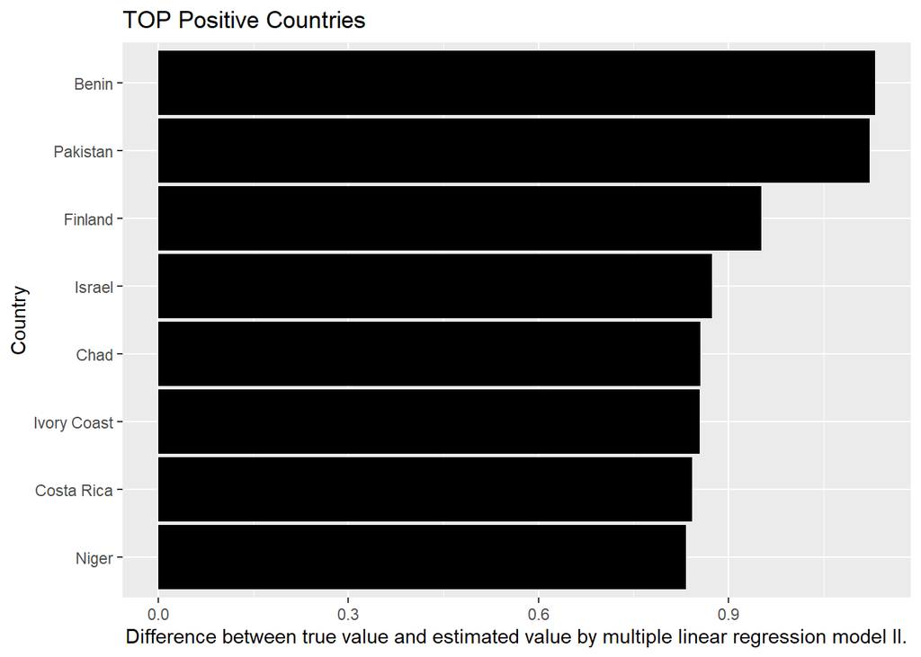

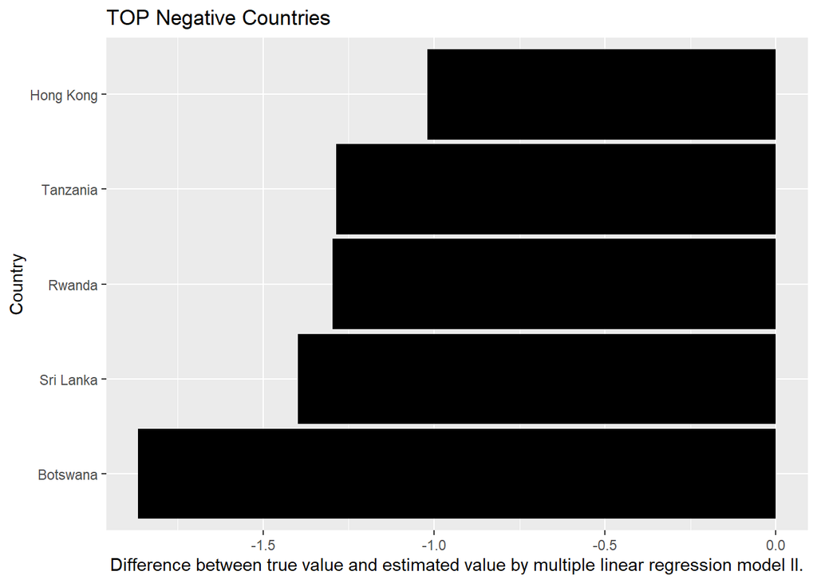